# Supervised Learning - Neural Network

Liah Cha

June 27, 2017

## Neural Networks (NN)

- AN algorithm for estimation or classification (비선형)
- Magical and mysterious hype, but just a non-linear statistical model
- Can be thought of as a generalization of regression (회귀분석의 일반화)
- “Universal approximator” 범용근사기

## Hidden Nodes

- Hidden layer nodes
- These nodes consists two parts
  - Combination function (결합함수)
  - Activation function (활성함수)

## Activation (Squashing) Function

1. Sigmoid(logistic), hyperbolic tangent functions
   - 미분가능함, 출력값 급격한 변화없는 S자 curve가 만들어짐
2. Simple functions: Linear, Threshold
3. Gaussian function: RBF(Radial Basis Function) Network
- 어떤 활성함수를 쓰느냐에 따라 결과가 많이 바뀌지는 않음 기본적으로 S자 커브이기 때문

## Mathematical formuation

#### Training the Networks

- W를 발견해내는 부분 : 목적함수(예측오차)를 최소화 시키는 기준
- Training the NN menas finding a set of weights that minimize the predictive error for the records in the training set
- Many numerical methods can be used for doing this; classical one called **back propagation(역전파)**
- Back propagation recommends Quasi-Newton for medium size problems, conjugate gradient for large problems
- All suffer from stopping at local minima; common fix is to select many random starting values and save the best solution
  - 수렴하긴 하지만, global minimum이 아니라 local minimum 일 수 있음

## Cost function (목적함수)

## Example : BUYTEST

| 범주 | 변수 | 변수의 내용 |
| --- | --- | --- |
| 인구속성 | Age | 나이(년) |
|  | Income | 년수입(1000$) |
|  | Married | 1:결혼, 0:미혼 |
|  | Sex | F:여자, M남자 |
|  | Ownhouse | 1:소유, 0:미소유 |
| 지역속성 | Loc | 거주지(A-H) |
|  | Climate | 거주지의 기온(10,20,30) |
| 거래회수 | Buy6 | 최근 6개월 간의 구입회수 |
|  | Buy12 | 최근 12개월 간의 구입회수 |
|  | Buy18 | 최근 18개월 간의 구입회수 |
|  | Buy24 | 최근 24개월 간의 구입회수 |
| 신용상태 | Fico | 신용점수 |
| 거래속성 | Orgsrc | 고객분류(C,D,I,O,P,R,U) |
|  | Discbuy | 할인고객 여부(1:할인고객, 0) |
|  | Return24 | 지난 24개월간 상품의 반품여부 (1:반품, 0) |
| 응답 | Respond | 광고메일에 응답여부(1:응답, 0) |
|  | Purchtot | 광고메일에 의한 구입총액 |
|  | C1-C7 | 광고메일에 의한 품목별 구입액 |
| 고객번호 | ID | 고객번호 |

```r
### Neural Network ###
buytest = read.table('./DMdata/buytest.txt',sep='\t',header=T)
head(buytest,10)
```

```
##           ID RESPOND AGE INCOME SEX MARRIED FICO OWNHOME LOC CLIMATE BUY6
## 1  001371057       0  71     67   M       1  719       0   A      10    1
## 2  002093270       0  53     72   M       1  751       0   A      10    0
## 3  002783726       0  53     70   F       1  725       0   A      10    1
## 4  010800860       0  45     56   F       0  684       0   A      10    0
## 5  014577797       0  32     66   F       0  651       0   A      10    0
## 6  015884859       0  35     48   F       0  691       1   A      10    0
## 7  017131376       0  43     49   F       0  694       1   A      10    0
## 8  018674857       0  39     64   M       0  659       0   A      10    0
## 9  019417226       0  66     65   M       0  692       0   A      10    0
## 10 021786286       0  NA     NA          NA  707      NA   A      10    0
##    BUY12 BUY18 VALUE24 ORGSRC DISCBUY RETURN24 COA6 C1 C2 C3 C4 C5 C6 C7
## 1      1     1     318      O       1        0    0  0  0  0  0  0  0  0
## 2      0     0      83      R       0        0    0  0  0  0  0  0  0  0
## 3      1     1     265      D       0        0    0  0  0  0  0  0  0  0
```

[output cut: 18 more lines]

```r
# Missing value가 하나라도 있으면 FALSE
complete=complete.cases(buytest[,c("RESPOND","AGE","FICO","BUY18")])
summary(complete) # complete 가 True 것으로만 분석
```

```
##    Mode   FALSE    TRUE    NA's
## logical     273    9727       0
```

```r
buytest1<-buytest[complete,]
nrow(buytest1)
```

```
## [1] 9727
```

```r
# nor = normalization min_max (0-1사이의 범위로 변환)
nor = function(x) {(x-min(x))/(max(x)-min(x))}
buytest1$AGE <- nor(buytest1$AGE)
buytest1$FICO <- nor(buytest1$FICO)
buytest1$BUY18 <- nor(buytest1$BUY18)

# Training : Test = 5 : 5 로 분할
set.seed(1234)
i = sample(1:nrow(buytest1), round(nrow(buytest1)*0.5)) #50% for training data, 30% for testdata
train = buytest1[i,]
test = buytest1[-i,]
#print0('Train: ', nrow(train), ', Test: ', nrow(test))
```

```r
#install.packages("neuralnet",repos="http://healthstat.snu.ac.kr/CRAN/")
library(neuralnet)

set.seed(1234)
# hidden=3, 은닉층의 갯수=3개
# stepmax=10,000 iteration의 max
# iteration 10,000번해서 수렴 못시키면 포기해라
# threshold = 0.01 : 값이 작을 수록
# act.fct = activation function 의 약어 = sigmoid'logistic'가 default 임
# linear.output=F 출력노드를 activation 안함 (만약 T이면, 회귀분석)
nn1<-neuralnet(RESPOND~AGE+FICO+BUY18, data=train, hidden=3,
stepmax = 1e+04, threshold = 0.01, act.fct='logistic', linear.output=F)
summary(nn1)
```

```
##                     Length Class      Mode
## call                    8  -none-     call
## response             4864  -none-     numeric
## covariate           14592  -none-     numeric
## model.list              2  -none-     list
## err.fct                 1  -none-     function
## act.fct                 1  -none-     function
## linear.output           1  -none-     logical
## data                   26  data.frame list
## net.result              1  -none-     list
## weights                 1  -none-     list
## startweights            1  -none-     list
## generalized.weights     1  -none-     list
## result.matrix          19  -none-     numeric
```

```r
print(nn1$weights)
```

```
## [[1]]
## [[1]][[1]]
##               [,1]           [,2]          [,3]
## [1,]   2.398464611   5.7372463927  14.139469681
## [2,]   8.363518343 -11.9999932479 -36.233129906
## [3,]   3.251933035   0.4765676299   4.653098954
## [4,] -28.249029104  -8.5303572788  -3.620079098
##
## [[1]][[2]]
##              [,1]
## [1,] -1.377162642
## [2,] -2.419953076
## [3,]  3.643624919
## [4,] -2.174313935
```

```r
head(nn1$net.result[[1]])
```

```
##               [,1]
## 1143 0.16330777538
## 6225 0.06141429107
## 6096 0.06424049512
## 6234 0.05659636874
## 8604 0.08920255379
## 6401 0.07917380639
```

```r
plot(nn1)
```

[output not shown]

```r
# hidden=c(3,3) 은닉층은 2개, 층마다 3개의 은닉노드
set.seed(1234)
nn2<-neuralnet(RESPOND~AGE+FICO+BUY18,data=train, hidden=c(3,3),
stepmax = 1e+04, threshold = 0.01, act.fct='logistic', linear.output=F)
plot(nn2)
```

[output not shown]

```r
pred1<-compute(nn1,covariate=test[,c("AGE","FICO","BUY18")])  ## 예측치
head(pred1$net.result,10)
```

```
##             [,1]
## 1  0.02506432140
## 2  0.04671500841
## 3  0.06290418437
## 5  0.07604300716
## 7  0.05788743462
## 9  0.02322634970
## 11 0.20181186968
## 12 0.08239877367
## 15 0.04999053363
## 17 0.08812091388
```

```r
pred2<-compute(nn2,covariate=test[,c("AGE","FICO","BUY18")])  ## 예측치
head(pred2$net.result,10)
```

```
##             [,1]
## 1  0.02753386454
## 2  0.06109418108
## 3  0.05704464454
## 5  0.06574350162
## 7  0.06469275412
## 9  0.05901257213
## 11 0.12087949048
## 12 0.06572918712
## 15 0.06682696410
## 17 0.06343663585
```

```r
library(pROC)
```

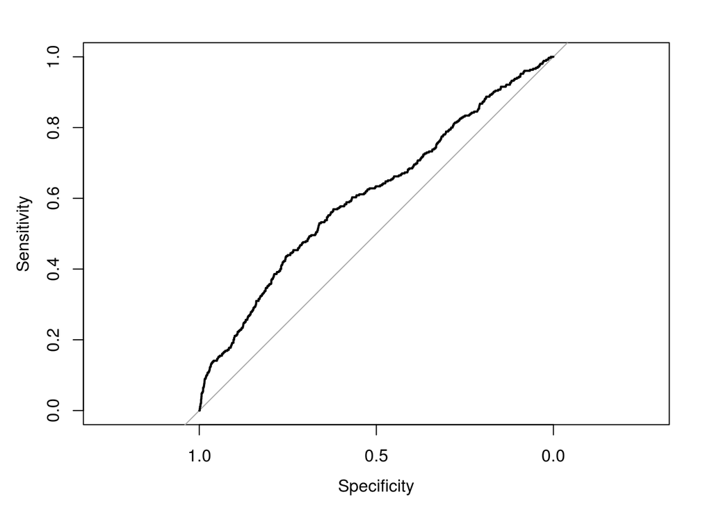

```r
roccurve1 <- roc(test$RESPOND ~ as.vector(pred1$net.result))
plot(roccurve1)
```

```r
auc(roccurve1)
```

```
## Area under the curve: 0.608462
```

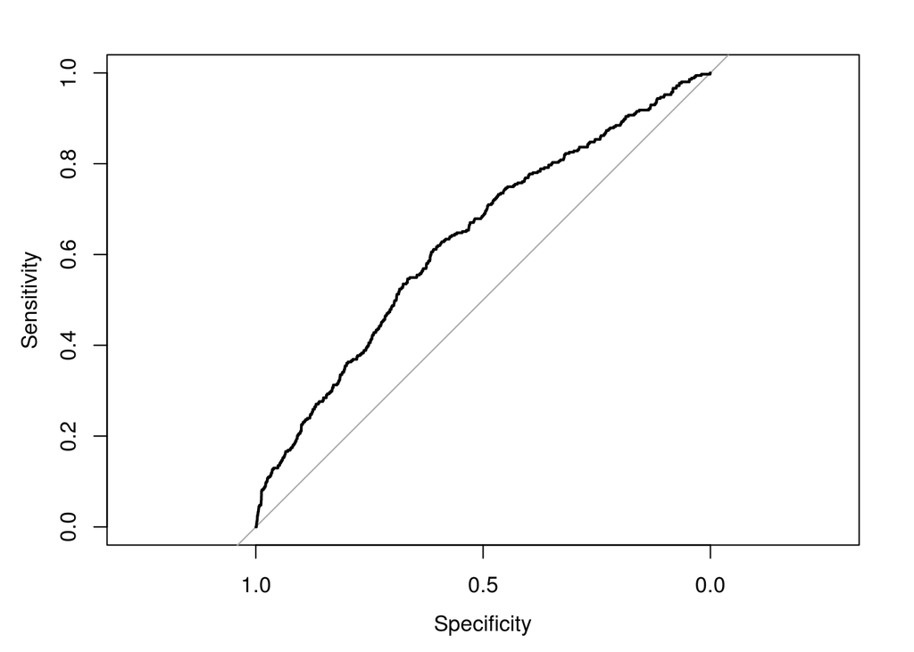

```r
roccurve2 <- roc(test$RESPOND ~ as.vector(pred2$net.result))
plot(roccurve2)
```

```r
auc(roccurve2)
```

```
## Area under the curve: 0.6324106
```

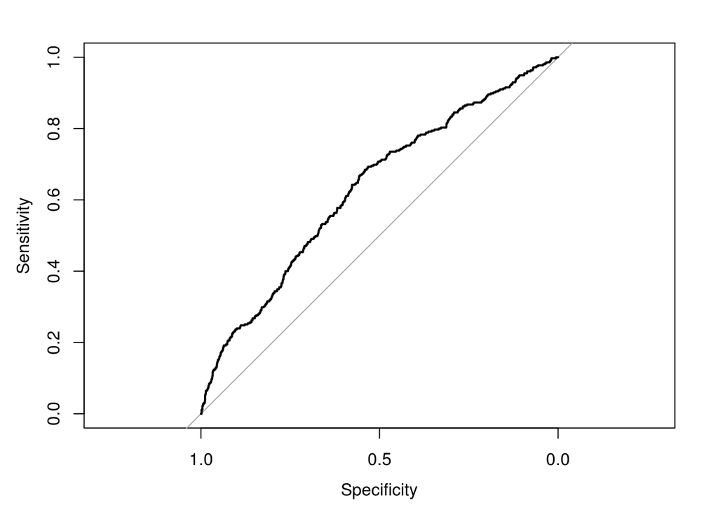

```r
logit1 = glm(RESPOND~AGE+FICO+BUY18,family=binomial(),data=train)
prob_pred1 = predict(logit1, newdata=test, type='response') ## predicted probability
roccurve3 <- roc(test$RESPOND ~ prob_pred1)
plot(roccurve3)
```

```r
auc(roccurve3)
```

```
## Area under the curve: 0.6313965
```